# CoDaCoRe Guide

Elliott Gordon-Rodriguez

3/12/2021

## Training the model

We assume a working installation of `codacore` ([link](https://github.com/egr95/R-codacore/blob/main/README.md)), as well as the `selbal` package ([link](https://github.com/UVic-omics/selbal/blob/master/vignettes/vignette.Rmd)), from which we will borrow the Crohn’s disease data (Gevers et al. 2014 http://dx.doi.org/10.1016/j.chom.2014.02.005).

```r
library("codacore")
library("selbal")
data("Crohn")
x <- Crohn[, -ncol(Crohn)]
y <- Crohn[, ncol(Crohn)]
```

Our goal is to identify ratio-based biomarkers that are predictive of disease status. Our input variable consists of the abundance of 48 microbial species in 975 samples.

```r
dim(x)
```

```
## [1] 975  48
```

The output variable is a binary indicator (CD stands for Chron’s disease).

```r
table(y)
```

```
## y
##  CD  no
## 662 313
```

Prior to fitting CoDaCoRe, we must impute any zeros in our input variable (a standard pre-processing step for ratio-based methods).

```r
x <- x + 1
```

Next, we split our data into a training and a test set (to keep things simple we do this naively at random, though in practice stratified sampling is preferable).

```r
# For reproducibility, we set a random seed (including in TensorFlow, used by codacore)
set.seed(0); library(tensorflow); tf$random$set_seed(0)
trainIndex <- sample(1:nrow(x), 0.8 * nrow(x))
xTrain <- x[trainIndex,]
yTrain <- y[trainIndex]
```

We are ready to fit CoDaCoRe. We stick to the default parameters for now. Notice the fast runtime (as compared to, for example, `selbal.cv`).

```r
model <- codacore(
  xTrain,
  yTrain,
  logRatioType = 'balances', # can also use 'amalgamations'
  lambda = 1                 # regularization parameter (1 corresponds to "1SE rule")
)
```

## Visualizing results

Next we can check the learned output of the model: what inputs were included in the learned log-ratios, how strongly associated they are to the response, and how well they classified the data.

```r
print(model)
```

```
##
## Number of log-ratios found: 2
## ***
## Log-ratio rank 1
## Numerator: g__Roseburia
## Denominator: g__Dialister
## AUC: 0.7306284
## Slope: 0.2642687
## ***
## Log-ratio rank 2
## Numerator: g__Parabacteroides f__Peptostreptococcaceae_g__ g__Bacteroides g__Faecalibacterium g__Roseburia g__Lachnospira o__Clostridiales_g__ f__Rikenellaceae_g__ g__Bilophila
## Denominator: g__Eggerthella g__Dialister g__Streptococcus g__Aggregatibacter
## AUC: 0.7788797
## Slope: 0.387607
```

The most predictive ratio identified by CoDaCoRe is Roseburia / Dialister, which can be visualized with the `plot` function.

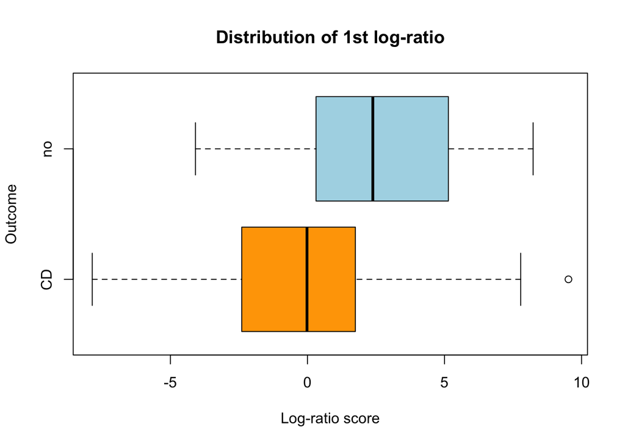

```r
plot(model)
```

Note that CoDaCoRe is an ensemble model, where multiple log-ratios are learned sequentially in decreasing order of importance (with automatic stopping whenever no additional log-ratio improved the loss function during training). We can visualize the performance of this ensembling procedure by “stacking” the respective ROC curves.

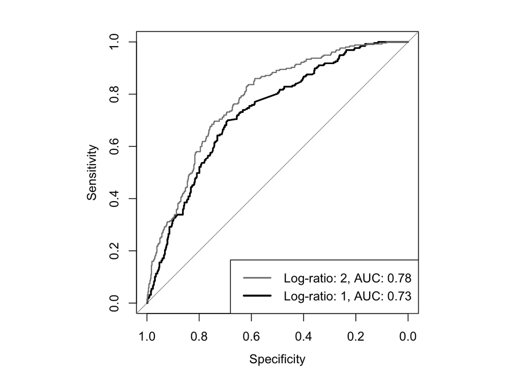

```r
plotROC(model)
```

## Predicting on new data

We can also use our trained model to classify new samples.

```r
xTest <- x[-trainIndex,]
yTest <- y[-trainIndex]
yHat <- predict(model, xTest, logits=F)
cat("Test set AUC =", pROC::auc(pROC::roc(yTest, yHat, quiet=T)))
```

```
## Test set AUC = 0.7980473
```

```r
# Convert probabilities into a binary class
failure <- yHat < 0.5
success <- yHat >= 0.5
yHat[failure] <- levels(y)[1]
yHat[success] <- levels(y)[2]
cat("Classification accuracy on test set =", round(mean(yHat == yTest), 2))
```

```
## Classification accuracy on test set = 0.75
```

Other useful functions include:

```r
getNumeratorParts(model, 1)
getDenominatorParts(model, 1)
getLogRatios(model, xTest)
```

## Using amalgamations (summed-log-ratios)

CoDaCoRe can be used to learn log-ratios between both geometric means (known as “balances” or “isometric-log-ratio”) or summations (known as “amalgamations” or “summed-log-ratio”), depending on the goals of the user. This can be specified with the parameter `logRatioType`.

```r
model <- codacore(xTrain, yTrain, logRatioType = "amalgamations")
print(model)
```

```
##
## Number of log-ratios found: 1
## ***
## Log-ratio rank 1
## Numerator: g__Parabacteroides g__Bacteroides g__Faecalibacterium o__Clostridiales_g__
## Denominator: g__Haemophilus f__Enterobacteriaceae_g__ g__Dialister g__Streptococcus g__Fusobacterium
## AUC: 0.6959698
## Slope: 0.3204152
```

Note that amalgamations/summed-log-ratios are less sensitive to covariates that are small in magnitude (e.g., rare microbes), which can hinder their predictive strength for datasets where small covariates are important. On the other hand, summed-log-ratios have a different interpretation than isometric-log-ratios and may therefore be preferrable in some applications (e.g., when the “summed” effect of an aggregated sub-population is the object of interest). In our Crohn’s disease data, the rare species Roseburia gets picked up by the isometric-log-ratio, but not by the summed-log-ratio, which is more sensitive to more common bacteria species such as Faecalibacterium.

## Continuous outcomes

We consider the HIV data from (Noguera-Julian et al. 2016 http://dx.doi.org/10.1016/j.ebiom.2016.01.032), which again we take from the `selbal` package. The goal here is to construct a log-ratio of the microbial abundances that is predictive of the inflammation marker “sCD14”, a continuous response variable. CoDaCoRe can be applied much in the same way, except the loss function changes from binary cross-entropy to mean-squared-error. This change will happen automatically based on the values received from `y` (although it can also be overriden manually via the `objective` parameter, for example, if the user wanted to fit a binary response using the mean-squared-error, they could specify `objective = 'regression'`).

```r
data("sCD14")
x <- sCD14[, -ncol(sCD14)]
y <- sCD14[, ncol(sCD14)]

# Replace zeros as before
x <- x + 1

# Split the data
trainIndex <- sample(1:nrow(x), 0.8 * nrow(x))
xTrain <- x[trainIndex,]
yTrain <- y[trainIndex]

# Fit codacore and inspect results
model <- codacore(xTrain, yTrain)
print(model)
```

```
##
## Number of log-ratios found: 1
## ***
## Log-ratio rank 1
## Numerator: g_Clostridium_sensu_stricto_1 g_Desulfovibrio
## Denominator: g_Collinsella
## R squared: 0.1766855
## Slope:
```

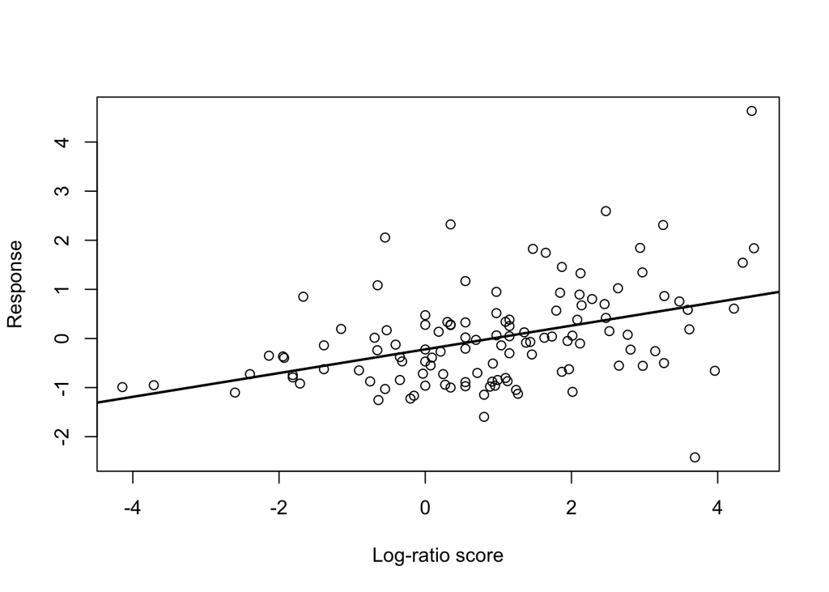

```r
plot(model)
```

## Tuning lambda

The parameter lambda controls the regularization strength of CoDaCoRe. In particular, lambda = 1 (the default value) corresponds to applying the 1-standard-error rule in the discretization step of the log-ratio (details in [Section 3.3](https://www.biorxiv.org/content/10.1101/2021.02.11.430695v1.full.pdf)). This is typically a good choice, leading to models that are very sparse and also performant. Sparser models can be achieved by higher values of lambda, for example, lambda = 2 corresponds to applying a “2-standard-error” rule. On the other hand, smaller values of lambda result in less sparse, but typically more predictive, models. In particular, lambda = 0 corresponds to no standard-error rule, in other words choosing the log-ratio that minimizes cross-validation score. Such a choice can be good when we seek a maximally predictive model, but care less about sparsity.

```r
model <- codacore(xTrain, yTrain, lambda = 0.0)
print(model)
```

```
##
## Number of log-ratios found: 4
## ***
## Log-ratio rank 1
## Numerator: g_Alistipes g_Subdoligranulum g_Dialister g_Clostridium_sensu_stricto_1 f_Peptostreptococcaceae_g_Incertae_Sedis g_Desulfovibrio
## Denominator: f_Lachnospiraceae_g_unclassified g_Blautia g_Lachnospira g_Catenibacterium g_Mitsuokella g_Sutterella g_Bifidobacterium g_Collinsella
## R squared: 0.2521796
## Slope:
## ***
## Log-ratio rank 2
## Numerator: g_Desulfovibrio
## Denominator: g_Collinsella
## R squared: 0.2690658
## Slope:
## ***
## Log-ratio rank 3
## Numerator: g_Desulfovibrio
## Denominator: g_Catenibacterium g_Sutterella g_Collinsella
## R squared: 0.2752558
## Slope:
## ***
## Log-ratio rank 4
## Numerator: g_Desulfovibrio
## Denominator: g_Lachnospira g_Catenibacterium g_Mitsuokella g_Sutterella g_Bifidobacterium g_Collinsella
## R squared: 0.2762911
## Slope:
```

Notice the increased R-squared score relative to the previous model (at the expense of sparsity).

## Additional covariates

Many applications require accounting for potential confounder variables as well as our ratio-based biomarkers. As an example, we consider a second HIV dataset from (Noguera-Julian et al. 2016 http://dx.doi.org/10.1016/j.ebiom.2016.01.032), which is also available from the `selbal` package. The goal is to find a microbial signature for HIV status, i.e., a log-ratio that can discriminate between HIV-positive and HIV-negative individuals. However, we have an additional confounder variable, MSM (Men who have Sex with Men). There are multiple approaches that can be used to account for the effect of this covariate in the context of a CoDaCoRe model. One of the simplest approaches would be to start by “partialling out” this variable, by regressing HIV status on MSM, and then training CoDaCoRe on the “residual”. Note that this is a natural approach in the context of CoDaCoRe, given the ensembling (i.e. stagewise additive) nature of our model. This is easily done by means of the `offset` parameter.

```r
data("HIV")
x <- HIV[, 1:(ncol(HIV) - 2)]
z <- HIV[, ncol(HIV) - 1]
y <- HIV[, ncol(HIV)]

# Replace zeros as before
x <- x + 1

# Split the data
trainIndex <- sample(1:nrow(x), 0.8 * nrow(x))
xTrain <- x[trainIndex,]
zTrain <- z[trainIndex]
yTrain <- y[trainIndex]

partial <- glm(yTrain ~ zTrain, family='binomial')
model <- codacore(xTrain, yTrain, offset=partial$fitted.values)
print(model)
```

```
##
## Number of log-ratios found: 1
## ***
## Log-ratio rank 1
## Numerator: g_Bacteroides
## Denominator: g_RC9_gut_group
## AUC: 0.780303
## Slope: 0.2721062
```

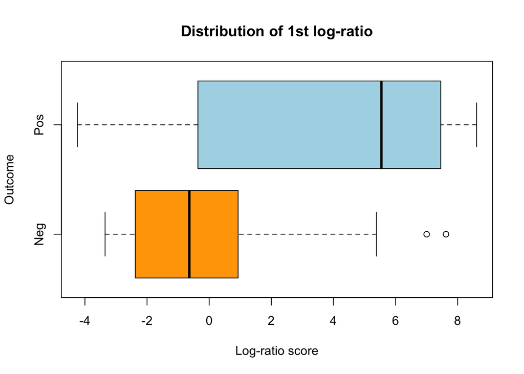

```r
plot(model)
```

```r
partialAUC <- pROC::auc(pROC::roc(yTrain, partial$fitted.values, quiet=T))
codacoreAUC <- model$ensemble[[1]]$AUC
cat("AUC gain:", round(100 * (codacoreAUC - partialAUC)), "%")
```

```
## AUC gain: 12 %
```

## Controlling overlap between log-ratios

By default, CoDaCoRe allows for “overlapping log-ratios”, in other words, a covariate that is included in the first log-ratio may well be included in a second or third log-ratio provided it is sufficiently predictive. In a future version of the package, we will include a parameter that allows the user to control this behaviour, supporting both “overlapping log-ratios” as well as “mutually exclusive log-ratios”, where each log-ratio must be constructed from a different set of covariates.

## Unsupervised Learning

Coming soon…

## Multi-omics integration

Coming soon…